# Chelicerate species trees

```r
knitr::opts_chunk$set(echo = TRUE, warning = FALSE, message = FALSE)

library(ggplot2)
library(cowplot)
#library(ggbeeswarm)
library(dplyr)
library(kableExtra)
#library(tidyr)
library(ggtree)
#library(phytools)
#library(phangorn)
#library(reshape2)
library(ggExtra)
#library(ggrepel)
#library(vroom)
#library(ggdist)
#library(stringr)
#library(ggsignif)
library(here)
source("../lib/design.r")
source("../lib/get_tree_info.r")
#source("C:/Users/grt814/bin/core/corelib/design.r")
#source("C:/Users/grt814/bin/core/get_tree_info.r")

#ggtree::rotate <- ggtree::rotate()

#htmltools::includeHTML("../html-chunks/rmd_nav.html")
```

< Back to project

```r
save_tree_fig = F
# Meta options. Comment tree_type when running form generator

genome_file = here("data", "chelicerate_genomes-gwct.csv")

summary_file = here("data", "gene-trees.csv")

pro_tree_file = here("data", "trees", "chelicerate-19spec-astral-pro-rooted.tre")
#pro_pep_tree_file = here("data", "trees", "chelicerate-19spec-pep-astral-pro-rooted.tre")
pro_info_out = here("data", "trees", "chelicerate-19spec-astral-pro-info-rooted.csv")
pro_info_file = here("data", "trees", "chelicerate-19spec-astral-pro-info-labeled-rooted.csv")

pro_tree_file_16 = here("data", "16spec", "trees", "chelicerate-16spec-astral-pro.rooted.tre")

multi_tree_file = here("data", "trees", "chelicerate-19spec-astral-multi-rooted.tre")
#multi_pep_tree_file = here("data", "trees", "chelicerate-19spec-pep-astral-multi-rooted.tre")
multi_info_out = here("data", "trees", "chelicerate-19spec-astral-multi-info.rooted-csv")
multi_info_file = here("data", "trees", "chelicerate-19spec-astral-multi-info-labeled-rooted.csv")

single_tree_file = here("data", "trees", "chelicerate-19spec-astral-single-copy-rooted.tre")
#single_pep_tree_file = here("data", "trees", "chelicerate-19spec-pep-astral-single-copy.rooted.tre")
single_info_out = here("data", "trees", "chelicerate-19spec-astral-single-copy-info-rooted.csv")
single_info_file = here("data", "trees", "chelicerate-19spec-astral-single-copy-info-labeled-rooted.csv")

ballesteros_topology_file = here("data", "trees", "ballesteros.tre")
traditional_topology_file = here("data", "trees", "traditional.tre")

genome_data = read.csv(genome_file, header=T)
genome_data = subset(genome_data, Include=="Y")

spec_abbrs = select(genome_data, S.name, Abbr)
names(spec_abbrs)[2] = "label"
```

# 1 Gene tree summary

Note that status refers only to the rooting process. All 9629 gene trees were used for ASTRAL-pro and ASTRAL-multi.

```r
gt_data = read.csv(summary_file, header=T)

gt_data %>% kable() %>% kable_styling(bootstrap_options=c("striped", "condended", "responsive"), full_width=F)
```

| Step | Status.action.taken | Count |
| --- | --- | --- |
| Gene trees successfully inferred | Initial | 11017 |
| Gene trees without outgroup | Removed | 4479 |
| Gene trees with both outgroups, but not rooted | Removed | 179 |
| Gene trees rooted by DMELA | Retained | 1780 |
| Gene trees rooted by BMORI | Retained | 698 |
| Gene trees rooted by both outgroups | Retained | 3881 |
| Gene trees rooted (total) | Final | 6359 |
| Single copy gene trees | Initial | 208 |
| Single copy gene trees rooted | Final | 208 |

# 2 ASTRAL-pro species tree

All branches have full ASTRAL support (1.0).

Note: Tip branch lengths arbitrarily set to average of internal branch lengths…

#### 2.0.0.1 [Newick tree file (CDS; rooted)](https://github.com/gwct/spider-wgd/blob/main/data/trees/chelicerate-19spec-astral-pro-rooted.tre)

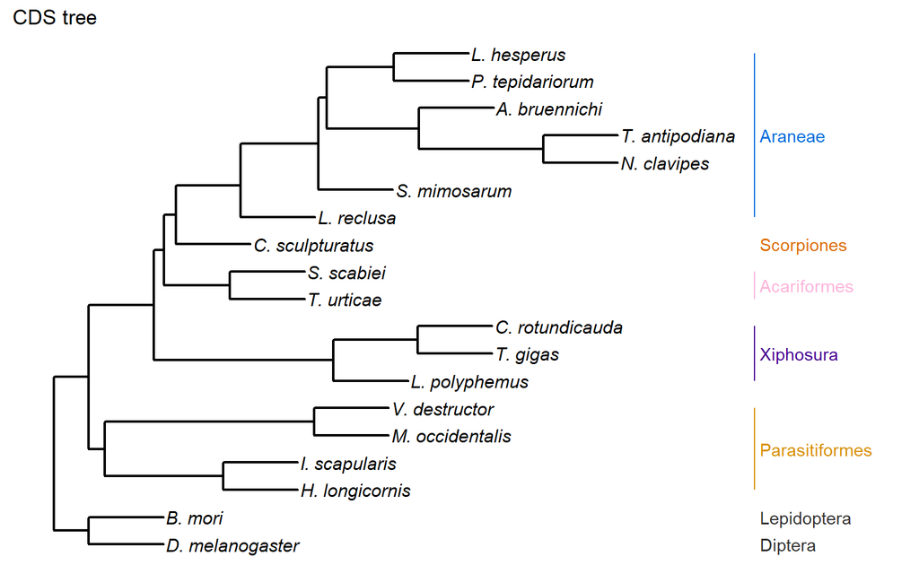

```r
orig_pro_tree = read.tree(pro_tree_file)

tree_to_df_list = treeToDF(orig_pro_tree, add_avg_bl=TRUE)
pro_info = tree_to_df_list[["info"]]
pro_tree = tree_to_df_list[["labeled.tree"]]
# Parse the tree info, and replace the tip branch lengths
# with the avg. internal branch lengths as "labeled.tree"

pro_info = merge(pro_info, spec_abbrs, by="label", all=TRUE)
pro_info = pro_info[order(pro_info$node), ]
# Merge the fulle species names and re-order the rows by the R node

h = corecol(numcol=1, pal="wilke", offset=3)
l = corecol(numcol=1, offset=3)
# Colors

famcol = corecol(pal="wilke", numcol=1, offset=2)
famoffset = 2
# Order labels

pro_cds_tree_fig = ggtree(pro_tree, size=0.8, ladderize=T) +#, aes(color=full_data$Family)) +
  xlim(0, 13) +
  geom_tiplab(aes(label=pro_info$S.name), fontface='italic', size=4) +
  #scale_color_manual(name='Include?', values=c("N"=corecol(pal="wilke", numcol=1,offset=1), "Y"=corecol(numcol=1, offset=1))) +
  #geom_text(aes(label=node), hjust=-.3, vjust=-.3, color="#ff6db6") +

  geom_cladelabel(node=32, label="Araneae", align=T, color=corecol(numcol=1, offset=2), offset=famoffset) +
  geom_cladelabel(node=12, label="Scorpiones", align=T, color=corecol(numcol=1), offset=famoffset) +
  geom_cladelabel(node=27, label="Xiphosura", align=T, color=corecol(numcol=1, offset=4), offset=famoffset) +
  geom_cladelabel(node=30, label="Acariformes", align=T, color=corecol(numcol=1, offset=7), offset=famoffset) +
  geom_cladelabel(node=23, label="Parasitiformes", align=T, color=corecol(numcol=1, offset=1, pal="trek"), offset=famoffset) +
  geom_cladelabel(node=1, label="Diptera", align=T, color="#333333", offset=famoffset) +
  geom_cladelabel(node=2, label="Lepidoptera", align=T, color="#333333", offset=famoffset) +
  ggtitle("CDS tree")

  #theme(legend.position=c(0.05,0.9))

  pro_cds_tree_fig = pro_cds_tree_fig %>% ggtree::rotate(34) %>% ggtree::rotate(35) %>% ggtree::rotate(37)

print(pro_cds_tree_fig)
```

```r
#### [Newick tree file (peptides; rooted)](https://github.com/gwct/spider-wgd/blob/main/data/trees/chelicerate-16spec-pep-astral-pro.rooted.tre)

orig_pro_pep_tree = read.tree(pro_pep_tree_file)

tree_to_df_list = treeToDF(orig_pro_pep_tree, add_avg_bl=TRUE)
pro_pep_info = tree_to_df_list[["info"]]
pro_pep_tree = tree_to_df_list[["labeled.tree"]]
# Parse the tree info, and replace the tip branch lengths
# with the avg. internal branch lengths as "labeled.tree"

pro_pep_info = merge(pro_pep_info, spec_abbrs, by="label", all=TRUE)
pro_pep_info = pro_pep_info[order(pro_pep_info$node), ]
# Merge the fulle species names and re-order the rows by the R node

h = corecol(numcol=1, pal="wilke", offset=3)
l = corecol(numcol=1, offset=3)
# Colors

famcol = corecol(pal="wilke", numcol=1, offset=2)
famoffset = 6
# Order labels

pro_pep_tree_fig = ggtree(pro_pep_tree, size=0.8, ladderize=T) +#, aes(color=full_data$Family)) +
  xlim(0, 19) +
  geom_tiplab(aes(label=pro_pep_info$S.name), fontface='italic', size=4) +
  #scale_color_manual(name='Include?', values=c("N"=corecol(pal="wilke", numcol=1,offset=1), "Y"=corecol(numcol=1, offset=1)))
  #geom_text(aes(label=node), hjust=-.3, vjust=-.3, color="#ff6db6")

  geom_cladelabel(node=22, label="Araneae", align=T, color=corecol(numcol=1, offset=2), offset=famoffset) +
  geom_cladelabel(node=7, label="Scorpiones", align=T, color=corecol(numcol=1), offset=famoffset) +
  geom_cladelabel(node=27, label="Xiphosura", align=T, color=corecol(numcol=1, offset=4), offset=famoffset) +
  geom_cladelabel(node=30, label="Acariformes", align=T, color=corecol(numcol=1, offset=7), offset=famoffset) +
  geom_cladelabel(node=28, label="Parasitiformes", align=T, color=corecol(numcol=1, offset=1, pal="trek"), offset=famoffset) +
  geom_cladelabel(node=15, label="Diptera", align=T, color="#333333", offset=famoffset) +
  geom_cladelabel(node=16, label="Lepidoptera", align=T, color="#333333", offset=famoffset) +
  ggtitle("Peptide tree")

  #theme(legend.position=c(0.05,0.9))
#print(pro_pep_tree_fig)

pro_trees = plot_grid(pro_cds_tree_fig, pro_pep_tree_fig, ncol=2)
print(pro_trees)
```

# 3 ASTRAL-multi species tree

Inferred from 9629 gene trees using the ASTRAL, and the gene-to-species mapping method outlined here: https://github.com/smirarab/ASTRAL/blob/master/astral-tutorial.md#memory-issues-due-to-taxon-names.

All branches have full ASTRAL support (1.0).

Note: Tip branch lengths inferred by ASTRAL since this is treating the paralogs like multiple individuals in a species

#### 3.0.0.1 [Newick tree file (CDS; rooted)](https://github.com/gwct/spider-wgd/blob/main/data/trees/chelicerate-19spec-astral-multi-rooted.tre)

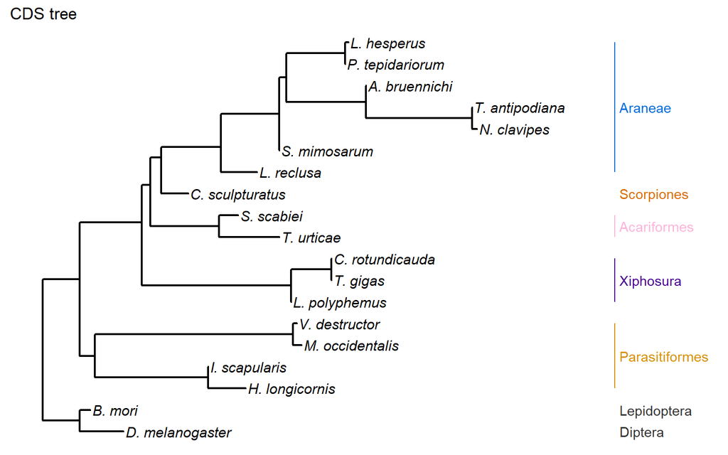

```r
orig_multi_tree = read.tree(multi_tree_file)

tree_to_df_list = treeToDF(orig_multi_tree)
multi_info = tree_to_df_list[["info"]]
multi_tree = tree_to_df_list[["labeled.tree"]]
# Parse the tree info, and replace the tip branch lengths
# with the avg. internal branch lengths as "labeled.tree"

multi_info = merge(multi_info, spec_abbrs, by="label", all=TRUE)
multi_info =multi_info[order(multi_info$node), ]
# Merge the fulle species names and re-order the rows by the R node

h = corecol(numcol=1, pal="wilke", offset=3)
l = corecol(numcol=1, offset=3)
# Colors

famcol = corecol(pal="wilke", numcol=1, offset=2)
famoffset = 2
# Order labels

multi_cds_tree_fig = ggtree(multi_tree, size=0.8, ladderize=F) +#, aes(color=full_data$Family)) +
  xlim(0, 10) +
  geom_tiplab(aes(label=multi_info$S.name), fontface='italic', size=4) +
  #scale_color_manual(name='Include?', values=c("N"=corecol(pal="wilke", numcol=1,offset=1), "Y"=corecol(numcol=1, offset=1))) +
  #geom_text(aes(label=node), hjust=-.3, vjust=-.3, color="#ff6db6") +

  geom_cladelabel(node=31, label="Araneae", align=T, color=corecol(numcol=1, offset=2), offset=famoffset) +
  geom_cladelabel(node=10, label="Scorpiones", align=T, color=corecol(numcol=1), offset=famoffset) +
  geom_cladelabel(node=27, label="Xiphosura", align=T, color=corecol(numcol=1, offset=4), offset=famoffset) +
  geom_cladelabel(node=37, label="Acariformes", align=T, color=corecol(numcol=1, offset=7), offset=famoffset) +
  geom_cladelabel(node=23, label="Parasitiformes", align=T, color=corecol(numcol=1, offset=1, pal="trek"), offset=famoffset) +
  geom_cladelabel(node=1, label="Diptera", align=T, color="#333333", offset=famoffset) +
  geom_cladelabel(node=2, label="Lepidoptera", align=T, color="#333333", offset=famoffset) +
  ggtitle("CDS tree")

  #theme(legend.position=c(0.05,0.9))

  multi_cds_tree_fig = multi_cds_tree_fig %>% ggtree::rotate(29) %>% ggtree::rotate(30) %>% ggtree::rotate(31) %>% ggtree::rotate(32) %>% ggtree::rotate(33) %>% ggtree::rotate(34) %>% ggtree::rotate(36) %>% ggtree::rotate(28) %>% ggtree::rotate(25) %>% ggtree::rotate(24)

print(multi_cds_tree_fig)
```

```r
#### [Newick tree file (peptide; rooted)](https://github.com/gwct/spider-wgd/blob/main/data/trees/chelicerate-16spec-pep-astral-multi.rooted.tre)

orig_multi_pep_tree = read.tree(multi_pep_tree_file)

tree_to_df_list = treeToDF(orig_multi_pep_tree)
multi_pep_info = tree_to_df_list[["info"]]
multi_pep_tree = tree_to_df_list[["labeled.tree"]]
# Parse the tree info, and replace the tip branch lengths
# with the avg. internal branch lengths as "labeled.tree"

multi_pep_info = merge(multi_pep_info, spec_abbrs, by="label", all=TRUE)
multi_pep_info =multi_pep_info[order(multi_pep_info$node), ]
# Merge the fulle species names and re-order the rows by the R node

h = corecol(numcol=1, pal="wilke", offset=3)
l = corecol(numcol=1, offset=3)
# Colors

famcol = corecol(pal="wilke", numcol=1, offset=2)
famoffset = 5
# Order labels

multi_pep_tree_fig = ggtree(multi_pep_tree, size=0.8, ladderize=F) +#, aes(color=full_data$Family)) +
  xlim(0, 15) +
  geom_tiplab(aes(label=multi_pep_info$S.name), fontface='italic', size=4) +
  #scale_color_manual(name='Include?', values=c("N"=corecol(pal="wilke", numcol=1,offset=1), "Y"=corecol(numcol=1, offset=1))) +
  #geom_text(aes(label=node), hjust=-.3, vjust=-.3, color="#ff6db6") +

  geom_cladelabel(node=27, label="Araneae", align=T, color=corecol(numcol=1, offset=2), offset=famoffset) +
  geom_cladelabel(node=8, label="Scorpiones", align=T, color=corecol(numcol=1), offset=famoffset) +
  geom_cladelabel(node=26, label="Xiphosura", align=T, color=corecol(numcol=1, offset=4), offset=famoffset) +
  geom_cladelabel(node=20, label="Acariformes", align=T, color=corecol(numcol=1, offset=7), offset=famoffset) +
  geom_cladelabel(node=22, label="Parasitiformes", align=T, color=corecol(numcol=1, offset=1, pal="trek"), offset=famoffset) +
  geom_cladelabel(node=1, label="Diptera", align=T, color="#333333", offset=famoffset) +
  geom_cladelabel(node=2, label="Lepidoptera", align=T, color="#333333", offset=famoffset) +
  ggtitle("Peptide tree")
  #theme(legend.position=c(0.05,0.9))

#multi_tree_fig = multi_tree_fig %>% ggtree::rotate(17) %>% ggtree::rotate(19) %>% ggtree::rotate(21) %>% ggtree::rotate(19) %>% ggtree::rotate(21)

#print(multi_pep_tree_fig)

multi_trees = plot_grid(multi_cds_tree_fig, multi_pep_tree_fig, ncol=2)
print(multi_trees)
```

# 4 ASTRAL species tree from 208 single-copy orthologs

Inferred from 208 single-copy orthologs using ASTRAL.

All branches have full ASTRAL support (1.0).

Note: Tip branch lengths arbitrarily set to average of internal branch lengths…

#### 4.0.0.1 [Newick tree file (CDS; rooted)](https://github.com/gwct/spider-wgd/blob/main/data/trees/chelicerate-19spec-astral-single-copy.tre)

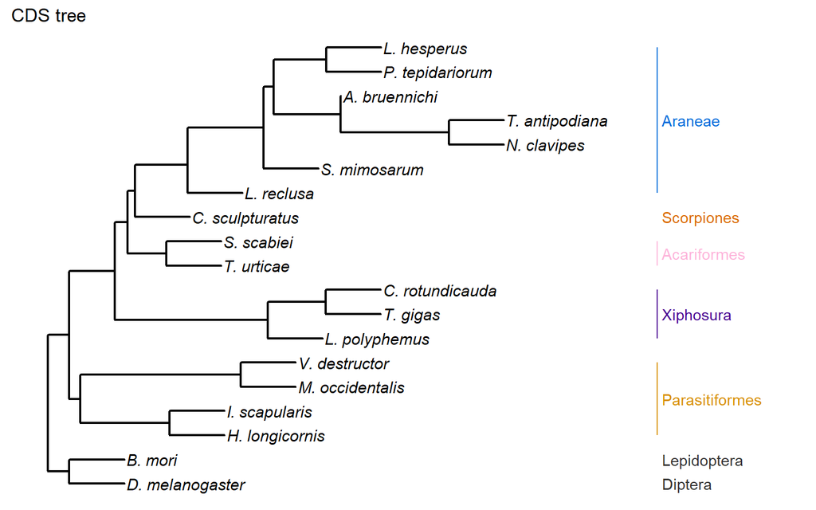

```r
orig_single_tree = read.tree(single_tree_file)

tree_to_df_list = treeToDF(orig_single_tree, add_avg_bl=TRUE)
single_info = tree_to_df_list[["info"]]
single_tree = tree_to_df_list[["labeled.tree"]]
# Parse the tree info, and replace the tip branch lengths
# with the avg. internal branch lengths as "labeled.tree"

single_info = merge(single_info, spec_abbrs, by="label", all=TRUE)
single_info =single_info[order(single_info$node), ]
# Merge the fulle species names and re-order the rows by the R node

h = corecol(numcol=1, pal="wilke", offset=3)
l = corecol(numcol=1, offset=3)
# Colors

famcol = corecol(pal="wilke", numcol=1, offset=2)
famoffset = 3
# Order labels

single_cds_tree_fig = ggtree(single_tree, size=0.8, ladderize=T) +#, aes(color=full_data$Family)) +
  xlim(0, 15) +
  geom_tiplab(aes(label=single_info$S.name), fontface='italic', size=4) +
  #scale_color_manual(name='Include?', values=c("N"=corecol(pal="wilke", numcol=1,offset=1), "Y"=corecol(numcol=1, offset=1))) +
  #geom_text(aes(label=node), hjust=-.3, vjust=-.3, color="#ff6db6") +

  geom_cladelabel(node=32, label="Araneae", align=T, color=corecol(numcol=1, offset=2), offset=famoffset) +
  geom_cladelabel(node=12, label="Scorpiones", align=T, color=corecol(numcol=1), offset=famoffset) +
  geom_cladelabel(node=27, label="Xiphosura", align=T, color=corecol(numcol=1, offset=4), offset=famoffset) +
  geom_cladelabel(node=30, label="Acariformes", align=T, color=corecol(numcol=1, offset=7), offset=famoffset) +
  geom_cladelabel(node=23, label="Parasitiformes", align=T, color=corecol(numcol=1, offset=1, pal="trek"), offset=famoffset) +
  geom_cladelabel(node=1, label="Diptera", align=T, color="#333333", offset=famoffset) +
  geom_cladelabel(node=2, label="Lepidoptera", align=T, color="#333333", offset=famoffset) +
  ggtitle("CDS tree")

  #theme(legend.position=c(0.05,0.9))

single_cds_tree_fig = single_cds_tree_fig %>% ggtree::rotate(34) %>% ggtree::rotate(35) %>% ggtree::rotate(30) %>% ggtree::rotate(28) %>% ggtree::rotate(23) %>% ggtree::rotate(24) %>% ggtree::rotate(25)

print(single_cds_tree_fig)
```

```r
#### [Newick tree file (peptide; rooted)](https://github.com/gwct/spider-wgd/blob/main/data/trees/chelicerate-16spec-pep-astral-single-copy.tre)

orig_single_pep_tree = read.tree(single_pep_tree_file)

tree_to_df_list = treeToDF(orig_single_pep_tree, add_avg_bl=TRUE)
single_pep_info = tree_to_df_list[["info"]]
single_pep_tree = tree_to_df_list[["labeled.tree"]]
# Parse the tree info, and replace the tip branch lengths
# with the avg. internal branch lengths as "labeled.tree"

single_pep_info = merge(single_pep_info, spec_abbrs, by="label", all=TRUE)
single_pep_info =single_pep_info[order(single_pep_info$node), ]
# Merge the fulle species names and re-order the rows by the R node

h = corecol(numcol=1, pal="wilke", offset=3)
l = corecol(numcol=1, offset=3)
# Colors

famcol = corecol(pal="wilke", numcol=1, offset=2)
famoffset = 8
# Order labels

single_pep_tree_fig = ggtree(single_pep_tree, size=0.8, ladderize=T) +#, aes(color=full_data$Family)) +
  xlim(0, 25) +
  geom_tiplab(aes(label=single_pep_info$S.name), fontface='italic', size=4) +
  #scale_color_manual(name='Include?', values=c("N"=corecol(pal="wilke", numcol=1,offset=1), "Y"=corecol(numcol=1, offset=1))) +
  #geom_text(aes(label=node), hjust=-.3, vjust=-.3, color="#ff6db6") +

  geom_cladelabel(node=24, label="Araneae", align=T, color=corecol(numcol=1, offset=2), offset=famoffset) +
  geom_cladelabel(node=3, label="Scorpiones", align=T, color=corecol(numcol=1), offset=famoffset) +
  geom_cladelabel(node=23, label="Xiphosura", align=T, color=corecol(numcol=1, offset=4), offset=famoffset) +
  geom_cladelabel(node=19, label="Acariformes", align=T, color=corecol(numcol=1, offset=7), offset=famoffset) +
  geom_cladelabel(node=29, label="Parasitiformes", align=T, color=corecol(numcol=1, offset=1, pal="trek"), offset=famoffset) +
  geom_cladelabel(node=15, label="Diptera", align=T, color="#333333", offset=famoffset) +
  geom_cladelabel(node=16, label="Lepidoptera", align=T, color="#333333", offset=famoffset) +
  ggtitle("Peptide tree")

  #theme(legend.position=c(0.05,0.9))

#multi_tree_fig = multi_tree_fig %>% ggtree::rotate(17) %>% ggtree::rotate(19) %>% ggtree::rotate(21) %>% ggtree::rotate(19) %>% ggtree::rotate(21)

#print(single_pep_tree_fig)

single_trees = plot_grid(single_cds_tree_fig, single_pep_tree_fig, ncol=2)
print(single_trees)
```

# 5 Notes relating to Ballesteros et al. 2022

https://academic.oup.com/mbe/article/39/2/msac021/6522129

They find:

1. Xiphosura consistently groups with Araneae and Scorpiones
2. Acariformes and Parasitiformes are not monophyletic. Their full tree (Fig. 1, Matrix 3) puts Acariformes outside of all other Parasitiformes, Xiphosura, Scorpiones, and Araneae.
3. Using their most stringent dataset (Matrix 4), Acariformes is sister to Xiphosura, but the lengths of the branches separating these groups from each other and from Araneae and Scorpiones are very short (Fig. 3).

```r
orig_trad_tree = read.tree(traditional_topology_file)

tree_to_df_list = treeToDF(orig_trad_tree, add_avg_bl=TRUE)
trad_info = tree_to_df_list[["info"]]
trad_tree = tree_to_df_list[["labeled.tree"]]
# Parse the tree info, and replace the tip branch lengths
# with the avg. internal branch lengths as "labeled.tree"

trad_info = merge(trad_info, spec_abbrs, by="label", all=TRUE)
trad_info =trad_info[order(trad_info$node), ]
# Merge the full species names and re-order the rows by the R node

h = corecol(numcol=1, pal="wilke", offset=3)
l = corecol(numcol=1, offset=3)
# Colors

famcol = corecol(pal="wilke", numcol=1, offset=2)
famoffset = 16
# Order labels

trad_tree_fig = ggtree(trad_tree, size=0.8, ladderize=T) +#, aes(color=full_data$Family)) +
  xlim(0, 30) +
  geom_tiplab(aes(label=trad_info$S.name), fontface='italic', size=4) +
  #scale_color_manual(name='Include?', values=c("N"=corecol(pal="wilke", numcol=1,offset=1), "Y"=corecol(numcol=1, offset=1))) +
  #geom_text(aes(label=node), hjust=-.3, vjust=-.3, color="#ff6db6") +

  geom_cladelabel(node=25, label="Ar", align=T, color=corecol(numcol=1, offset=2), offset=famoffset) +
  geom_cladelabel(node=8, label="S", align=T, color=corecol(numcol=1), offset=famoffset) +
  geom_cladelabel(node=35, label="X", align=T, color=corecol(numcol=1, offset=4), offset=famoffset) +
  geom_cladelabel(node=31, label="P", align=T, color=corecol(numcol=1, offset=7), offset=famoffset) +
  geom_cladelabel(node=34, label="Ac", align=T, color=corecol(numcol=1, offset=1, pal="trek"), offset=famoffset) +
  geom_cladelabel(node=18, label="D", align=T, color="#333333", offset=famoffset) +
  geom_cladelabel(node=19, label="L", align=T, color="#333333", offset=famoffset) +
  ggtitle("Monophyletic Arachnids")

  #theme(legend.position=c(0.05,0.9))

trad_tree_fig = trad_tree_fig %>% ggtree::rotate(27) %>% ggtree::rotate(30) %>% ggtree::rotate(29) %>% ggtree::rotate(31) %>% ggtree::rotate(32) %>% ggtree::rotate(36)

#print(trad_tree_fig)
```

```r
orig_ball_tree = read.tree(ballesteros_topology_file)

tree_to_df_list = treeToDF(orig_ball_tree, add_avg_bl=TRUE)
ball_info = tree_to_df_list[["info"]]
ball_tree = tree_to_df_list[["labeled.tree"]]
# Parse the tree info, and replace the tip branch lengths
# with the avg. internal branch lengths as "labeled.tree"

ball_info = merge(ball_info, spec_abbrs, by="label", all=TRUE)
ball_info =ball_info[order(ball_info$node), ]
# Merge the full species names and re-order the rows by the R node

h = corecol(numcol=1, pal="wilke", offset=3)
l = corecol(numcol=1, offset=3)
# Colors

famcol = corecol(pal="wilke", numcol=1, offset=2)
famoffset = 16
# Order labels

ball_tree_fig = ggtree(ball_tree, size=0.8, ladderize=T) +#, aes(color=full_data$Family)) +
  xlim(0, 30) +
  geom_tiplab(aes(label=ball_info$S.name), fontface='italic', size=4) +
  #scale_color_manual(name='Include?', values=c("N"=corecol(pal="wilke", numcol=1,offset=1), "Y"=corecol(numcol=1, offset=1))) +
  #geom_text(aes(label=node), hjust=-.3, vjust=-.3, color="#ff6db6") +

  geom_cladelabel(node=25, label="Ar", align=T, color=corecol(numcol=1, offset=2), offset=famoffset) +
  geom_cladelabel(node=8, label="S", align=T, color=corecol(numcol=1), offset=famoffset) +
  geom_cladelabel(node=31, label="X", align=T, color=corecol(numcol=1, offset=4), offset=famoffset) +
  geom_cladelabel(node=36, label="Ac", align=T, color=corecol(numcol=1, offset=7), offset=famoffset) +
  geom_cladelabel(node=33, label="P", align=T, color=corecol(numcol=1, offset=1, pal="trek"), offset=famoffset) +
  geom_cladelabel(node=18, label="D", align=T, color="#333333", offset=famoffset) +
  geom_cladelabel(node=19, label="L", align=T, color="#333333", offset=famoffset) +
  ggtitle("Ballesteros et al. 2021")

  #theme(legend.position=c(0.05,0.9))

ball_tree_fig = ball_tree_fig %>% ggtree::rotate(27) %>% ggtree::rotate(30) %>% ggtree::rotate(29) %>% ggtree::rotate(33) %>% ggtree::rotate(34)

#print(ball_tree_fig)
```

```r
famcol = corecol(pal="wilke", numcol=1, offset=2)
famoffset = 16
# Order labels

pro_cds_tree_nobl_fig = ggtree(pro_tree, size=0.8, ladderize=T, branch.length="none") +#, aes(color=full_data$Family)) +
  xlim(0, 30) +
  geom_tiplab(aes(label=pro_info$S.name), fontface='italic', size=4) +
  #scale_color_manual(name='Include?', values=c("N"=corecol(pal="wilke", numcol=1,offset=1), "Y"=corecol(numcol=1, offset=1))) +
  #geom_text(aes(label=node), hjust=-.3, vjust=-.3, color="#ff6db6") +

  geom_cladelabel(node=32, label="Ar", align=T, color=corecol(numcol=1, offset=2), offset=famoffset) +
  geom_cladelabel(node=12, label="S", align=T, color=corecol(numcol=1), offset=famoffset) +
  geom_cladelabel(node=27, label="X", align=T, color=corecol(numcol=1, offset=4), offset=famoffset) +
  geom_cladelabel(node=30, label="Ac", align=T, color=corecol(numcol=1, offset=7), offset=famoffset) +
  geom_cladelabel(node=23, label="P", align=T, color=corecol(numcol=1, offset=1, pal="trek"), offset=famoffset) +
  geom_cladelabel(node=1, label="D", align=T, color="#333333", offset=famoffset) +
  geom_cladelabel(node=2, label="L", align=T, color="#333333", offset=famoffset) +
  ggtitle("CDS tree")

  #theme(legend.position=c(0.05,0.9))

  pro_cds_tree_nobl_fig = pro_cds_tree_nobl_fig %>% ggtree::rotate(34) %>% ggtree::rotate(35) %>% ggtree::rotate(37)

#print(pro_cds_tree_nobl_fig)
```

```r
orig_pro_tree_16 = read.tree(pro_tree_file_16)

tree_to_df_list = treeToDF(orig_pro_tree_16, add_avg_bl=TRUE)
pro_info_16 = tree_to_df_list[["info"]]
pro_tree_16 = tree_to_df_list[["labeled.tree"]]
# Parse the tree info, and replace the tip branch lengths
# with the avg. internal branch lengths as "labeled.tree"

pro_info_16 = merge(pro_info_16, spec_abbrs, by="label", all=TRUE)
pro_info_16 = subset(pro_info_16, label!="HLONG" & label!="ABRUE" & label!="TGIGA")
pro_info_16 = pro_info_16[order(pro_info_16$node), ]
# Merge the fulle species names and re-order the rows by the R node

h = corecol(numcol=1, pal="wilke", offset=3)
l = corecol(numcol=1, offset=3)
# Colors

famcol = corecol(pal="wilke", numcol=1, offset=2)
famoffset = 16
# Order labels

pro_cds_tree_fig_16 = ggtree(pro_tree_16, size=0.8, ladderize=T, branch.length="none") +#, aes(color=full_data$Family)) +
  xlim(0, 30) +
  geom_tiplab(aes(label=pro_info_16$S.name), fontface='italic', size=4) +
  #scale_color_manual(name='Include?', values=c("N"=corecol(pal="wilke", numcol=1,offset=1), "Y"=corecol(numcol=1, offset=1))) +
  #geom_text(aes(label=node), hjust=-.3, vjust=-.3, color="#ff6db6") +

  geom_cladelabel(node=22, label="Ar", align=T, color=corecol(numcol=1, offset=2), offset=famoffset) +
  geom_cladelabel(node=7, label="S", align=T, color=corecol(numcol=1), offset=famoffset) +
  geom_cladelabel(node=27, label="X", align=T, color=corecol(numcol=1, offset=4), offset=famoffset) +
  geom_cladelabel(node=28, label="Ac", align=T, color=corecol(numcol=1, offset=7), offset=famoffset) +
  geom_cladelabel(node=29, label="P", align=T, color=corecol(numcol=1, offset=1, pal="trek"), offset=famoffset) +
  geom_cladelabel(node=15, label="D", align=T, color="#333333", offset=famoffset) +
  geom_cladelabel(node=16, label="L", align=T, color="#333333", offset=famoffset) +
  ggtitle("CDS tree (16 species)")

  #theme(legend.position=c(0.05,0.9))

  #pro_cds_tree_fig = pro_cds_tree_fig %>% ggtree::rotate(34) %>% ggtree::rotate(35) %>% ggtree::rotate(37)

#print(pro_cds_tree_fig_16)
```

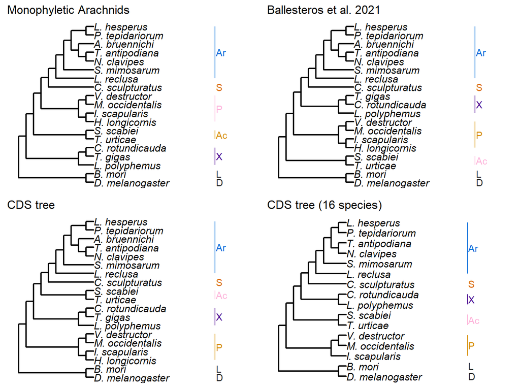

```r
other_trees = plot_grid(trad_tree_fig, ball_tree_fig, pro_cds_tree_nobl_fig, pro_cds_tree_fig_16, ncol=2)
print(other_trees)
```

```r
# Outline of algorithm to calculate gene concordance factors with paralogs

Basically, match clades between the species and gene tree and check for paralogs. If paralogs are present, remove them and then check if the branch is concordant.


for every gene tree{
  for every branch in the species tree{
    get the list of all species descending from this branch in the species tree

    find the LCA of these species in the gene tree

    get the list of species descening from the LCA in the gene tree

    if the list of species from the species tree branch and the gene tree branch match exactly{
      classify this branch as concordant for this gene tree
    }

    if list from the gene tree include species NOT in the species tree list{
      for each species not in the species tree list{
        if this species has another gene-copy present in the gene tree{
          consider as paralog and remove from gene tree list
        }
        else{
          keep in gene tree list
        }
      }

      if the gene tree list no longer contains species NOT in the species tree list{
        classify this branch as concordant for this gene tree
      }
      else{
        classify this branch as disconcordant for this gene tree
      }
    }
  }
}
```

< Back to project